# ## White Wine Quality by Kristin Lynch

> The data set analyzed was about the quality of white Portugese wines in 2009. There are multiple variables to test how they impact the quality rating of the wine.  
> Data was from this source:  
> P. Cortez, A. Cerdeira, F. Almeida, T. Matos and J. Reis. Modeling wine preferences by data mining from physicochemical properties. In Decision Support Systems, Elsevier, 47(4):547-553. ISSN: 0167-9236.

# Univariate Plots Section

> This section will show the table dimensions (rows, columns), as well as the column names and data types. The first six lines of the data frame have been printed.

```
## [1] 4898   13
```

```
## 'data.frame':    4898 obs. of  13 variables:
##  $ X                   : int  1 2 3 4 5 6 7 8 9 10 ...
##  $ fixed.acidity       : num  7 6.3 8.1 7.2 7.2 8.1 6.2 7 6.3 8.1 ...
##  $ volatile.acidity    : num  0.27 0.3 0.28 0.23 0.23 0.28 0.32 0.27 0.3 0.22 ...
##  $ citric.acid         : num  0.36 0.34 0.4 0.32 0.32 0.4 0.16 0.36 0.34 0.43 ...
##  $ residual.sugar      : num  20.7 1.6 6.9 8.5 8.5 6.9 7 20.7 1.6 1.5 ...
##  $ chlorides           : num  0.045 0.049 0.05 0.058 0.058 0.05 0.045 0.045 0.049 0.044 ...
##  $ free.sulfur.dioxide : num  45 14 30 47 47 30 30 45 14 28 ...
##  $ total.sulfur.dioxide: num  170 132 97 186 186 97 136 170 132 129 ...
##  $ density             : num  1.001 0.994 0.995 0.996 0.996 ...
##  $ pH                  : num  3 3.3 3.26 3.19 3.19 3.26 3.18 3 3.3 3.22 ...
##  $ sulphates           : num  0.45 0.49 0.44 0.4 0.4 0.44 0.47 0.45 0.49 0.45 ...
##  $ alcohol             : num  8.8 9.5 10.1 9.9 9.9 10.1 9.6 8.8 9.5 11 ...
##  $ quality             : int  6 6 6 6 6 6 6 6 6 6 ...
```

```
##   X fixed.acidity volatile.acidity citric.acid residual.sugar chlorides
## 1 1           7.0             0.27        0.36           20.7     0.045
## 2 2           6.3             0.30        0.34            1.6     0.049
## 3 3           8.1             0.28        0.40            6.9     0.050
## 4 4           7.2             0.23        0.32            8.5     0.058
## 5 5           7.2             0.23        0.32            8.5     0.058
## 6 6           8.1             0.28        0.40            6.9     0.050
##   free.sulfur.dioxide total.sulfur.dioxide density   pH sulphates alcohol
## 1                  45                  170  1.0010 3.00      0.45     8.8
## 2                  14                  132  0.9940 3.30      0.49     9.5
## 3                  30                   97  0.9951 3.26      0.44    10.1
## 4                  47                  186  0.9956 3.19      0.40     9.9
## 5                  47                  186  0.9956 3.19      0.40     9.9
## 6                  30                   97  0.9951 3.26      0.44    10.1
##   quality
## 1       6
## 2       6
## 3       6
## 4       6
## 5       6
## 6       6
```

> This section will show a summary of the variables. These variables will be explored closer by using graphs, but the summary reveals some points of interest to explore more closely.  
> 1) The max for residual sugar compared to the 3rd Quartile reveals that there are outliers.  
> 2) The min and max for total sulfur dioxide show the largest range of the variables.  
> 3) The quality scale is from 1 (very bad) to 10 (very excellent), but the range of values is from 3 to 9. With a median of 6, and a mean of 5.878, the wines skewed towards the higher quality.

```
##        X        fixed.acidity    volatile.acidity  citric.acid
##  Min.   :   1   Min.   : 3.800   Min.   :0.0800   Min.   :0.0000
##  1st Qu.:1225   1st Qu.: 6.300   1st Qu.:0.2100   1st Qu.:0.2700
##  Median :2450   Median : 6.800   Median :0.2600   Median :0.3200
##  Mean   :2450   Mean   : 6.855   Mean   :0.2782   Mean   :0.3342
##  3rd Qu.:3674   3rd Qu.: 7.300   3rd Qu.:0.3200   3rd Qu.:0.3900
##  Max.   :4898   Max.   :14.200   Max.   :1.1000   Max.   :1.6600
##  residual.sugar     chlorides       free.sulfur.dioxide total.sulfur.dioxide
##  Min.   : 0.600   Min.   :0.00900   Min.   :  2.00      Min.   :  9.0
##  1st Qu.: 1.700   1st Qu.:0.03600   1st Qu.: 23.00      1st Qu.:108.0
##  Median : 5.200   Median :0.04300   Median : 34.00      Median :134.0
##  Mean   : 6.391   Mean   :0.04577   Mean   : 35.31      Mean   :138.4
##  3rd Qu.: 9.900   3rd Qu.:0.05000   3rd Qu.: 46.00      3rd Qu.:167.0
##  Max.   :65.800   Max.   :0.34600   Max.   :289.00      Max.   :440.0
##     density             pH          sulphates         alcohol
##  Min.   :0.9871   Min.   :2.720   Min.   :0.2200   Min.   : 8.00
##  1st Qu.:0.9917   1st Qu.:3.090   1st Qu.:0.4100   1st Qu.: 9.50
##  Median :0.9937   Median :3.180   Median :0.4700   Median :10.40
##  Mean   :0.9940   Mean   :3.188   Mean   :0.4898   Mean   :10.51
##  3rd Qu.:0.9961   3rd Qu.:3.280   3rd Qu.:0.5500   3rd Qu.:11.40
##  Max.   :1.0390   Max.   :3.820   Max.   :1.0800   Max.   :14.20
##     quality
##  Min.   :3.000
##  1st Qu.:5.000
##  Median :6.000
##  Mean   :5.878
##  3rd Qu.:6.000
##  Max.   :9.000
```

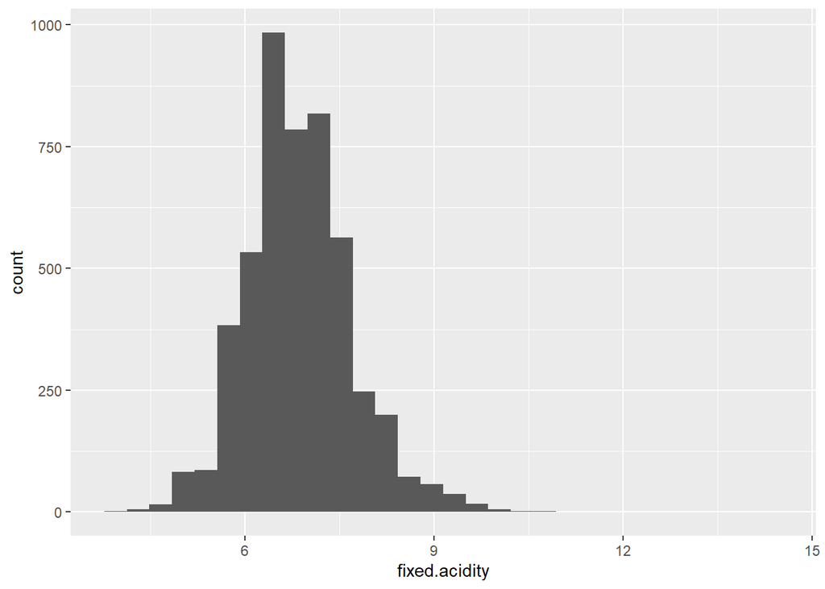

> The fixed acidity of the wine has most values between the six to seven range. We can use log to look at this in a different way since it has a long tail.

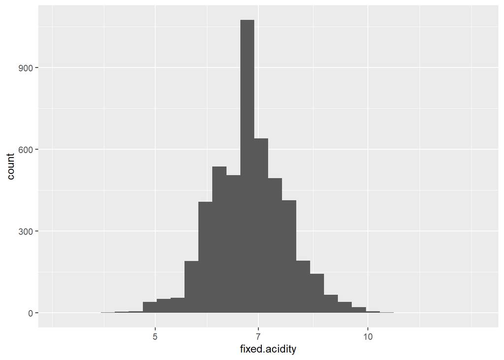

> By looking at this in log, we can see a more normal distribution.

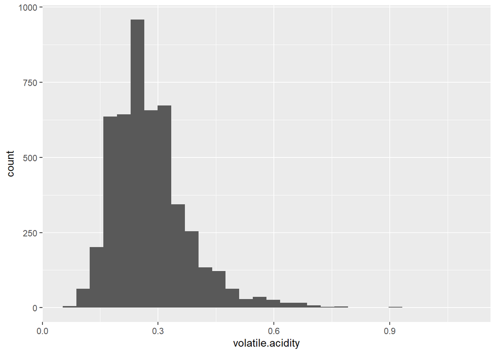

> High levels of volatile acidity can lead to an unpleasant taste according to the explanation on the data set.I’m wondering if those wines that are rated over .6 would have lower ratings than the rest of the wines because most wines fell under that value and that is well over the third quartile.

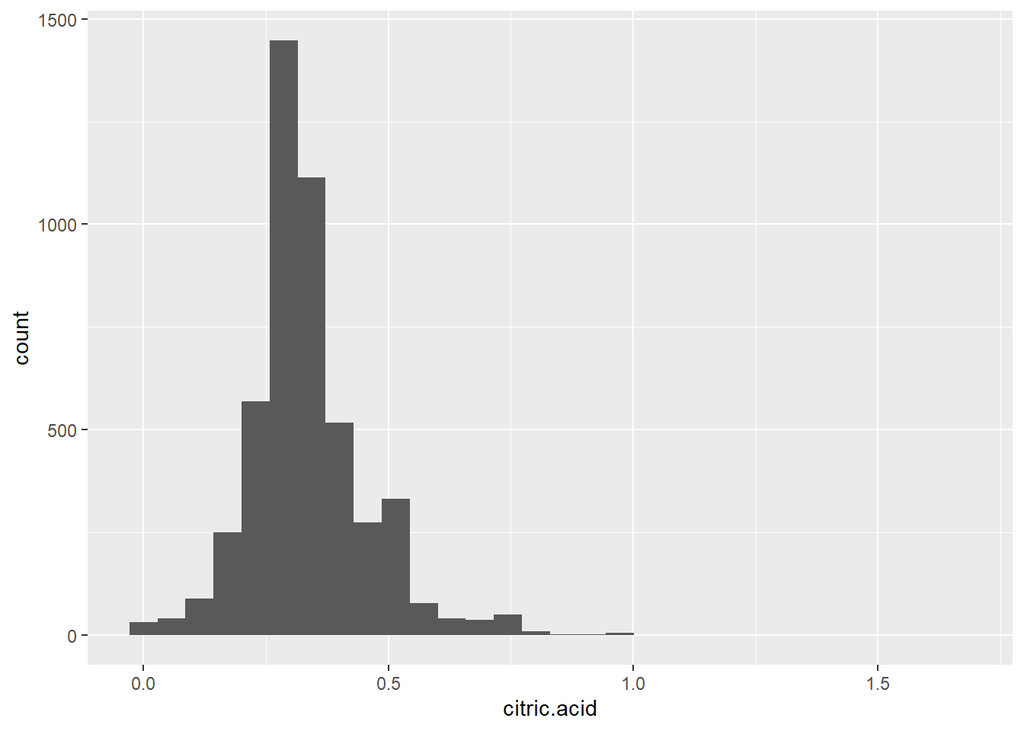

> Small quantities of citric acid can improve the taste of wine. I wonder if this will show in the analysis, and at what point will it stop increasing the quality?

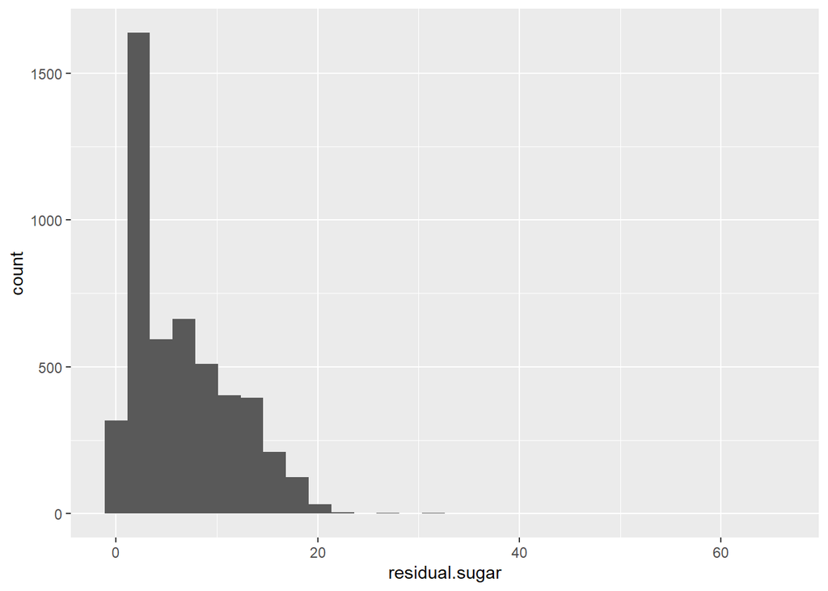

> The residual sugar was one of the most interesting variables to me because of the outliers. While sweet it normally a desired trait in some foods, in wine, it is normally in the range of 1 to 45 grams according to the information on the data set. I wonder if this has an impact on quality, since many people prefer dry wine so it’s more about preference and subjective.

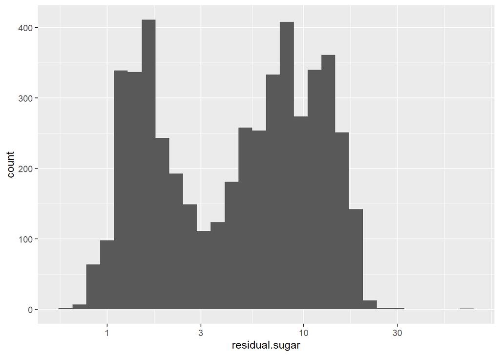

> Because of the long tail, I used the log 10 to transform this data. It shows a bimodal range of sugar, with a drop around 3. It’s possible this is due to trying to classify wines as dry or sweet and three would be hard to classify. We will need to look at this closer to see its correlation to quality.

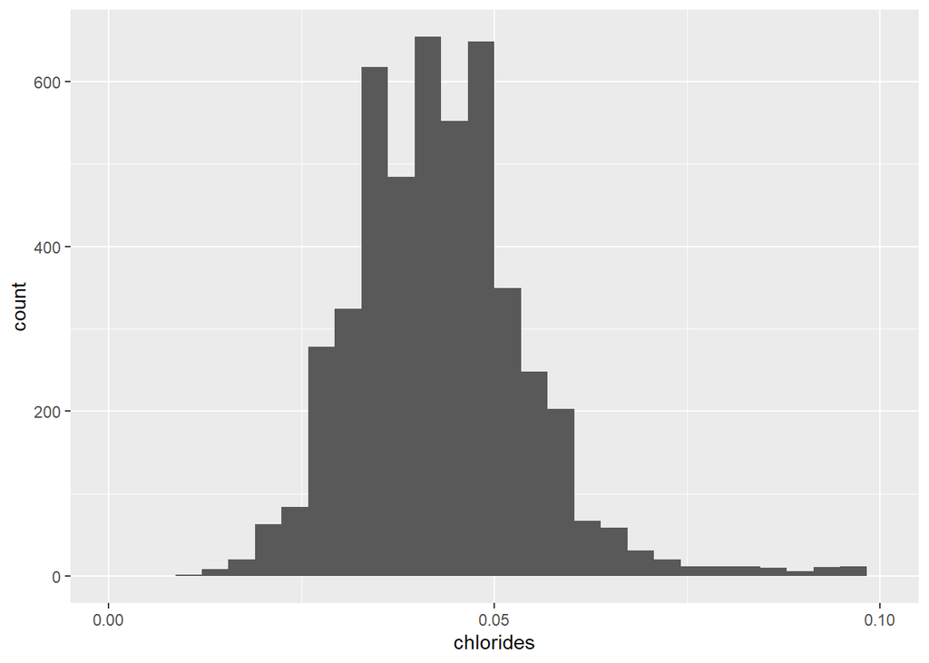

```
##    Min. 1st Qu.  Median    Mean 3rd Qu.    Max.
## 0.00900 0.03600 0.04300 0.04577 0.05000 0.34600
```

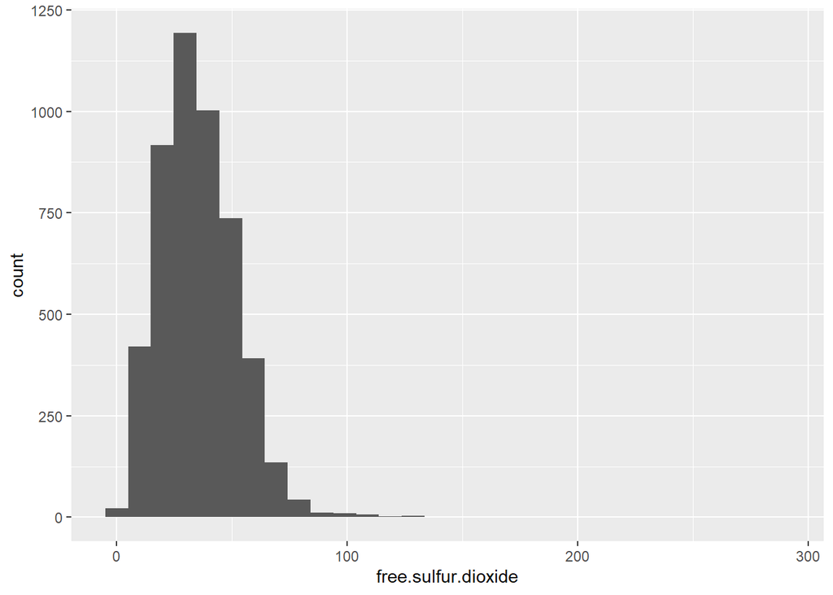

> Free sulfur dioxide prevents microbial growth according to the information about the data set. If this does impact quality, it would not be intentional like some of the other variables such as sweetness.

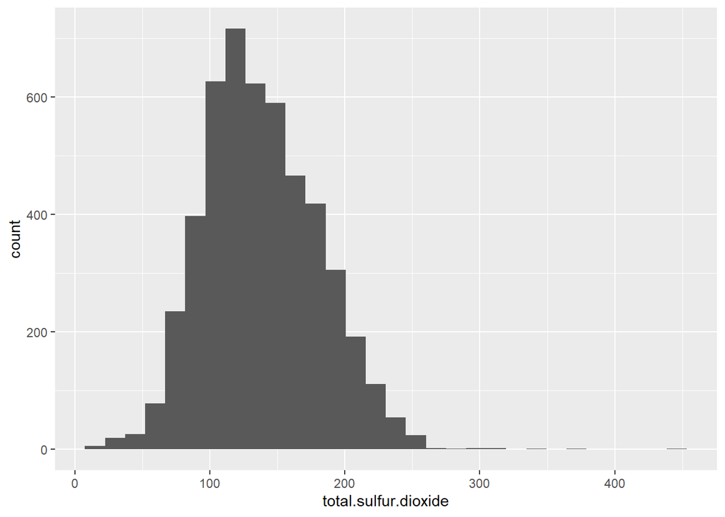

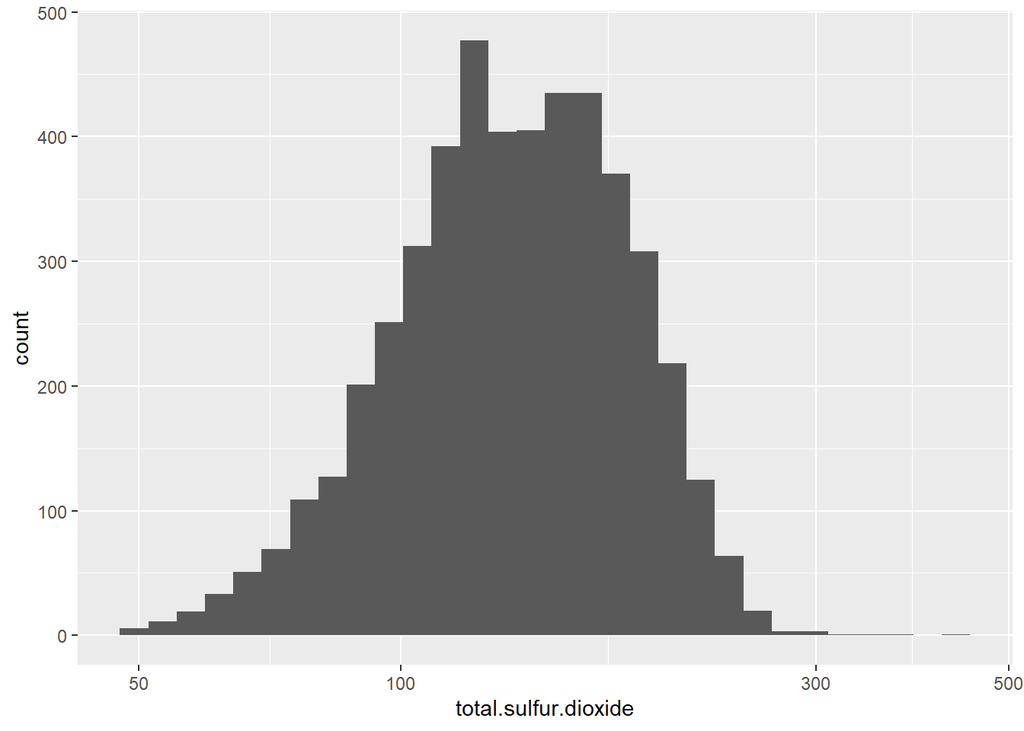

> According to the data set, only amounts over 50mg are detectable. I created a new variable for a data frame that only includes the detectable sulfur amounts to use on quality at a later point. I added log to this chart of the values over 50mg to include the long tail.

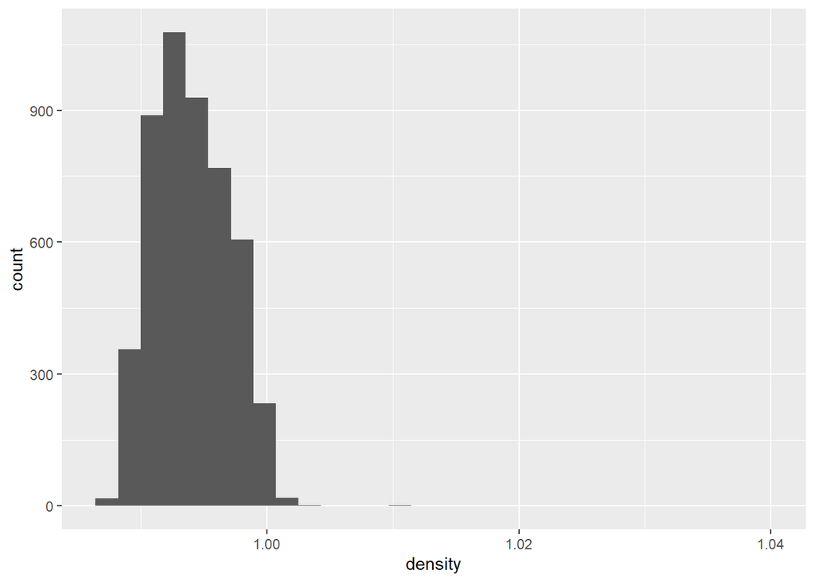

```
##    Min. 1st Qu.  Median    Mean 3rd Qu.    Max.
##  0.9871  0.9917  0.9937  0.9940  0.9961  1.0390
```

> The density of the wine is in the same range of water according to the text report. Water can change density at different temperatures according to google, but it is still in this range. I don’t see this variable as interesting as the others as I don’t think I have ever noticed a difference in my drinking water.

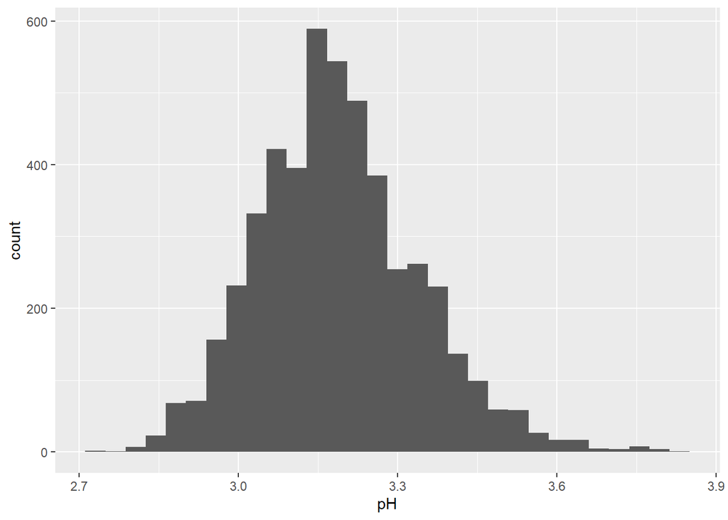

> This graph has a normal distribution. All wines in this study are acidic. They fall between the range of vinegar and tomato juice in similar examples.

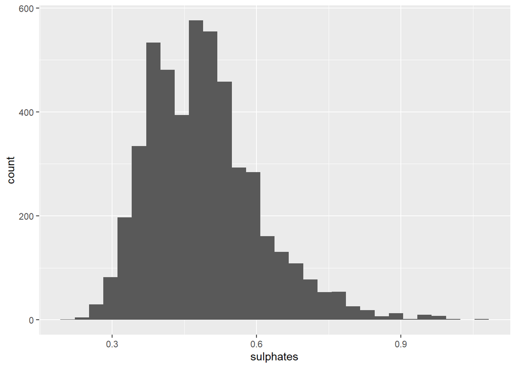

> Sulphates are not added to improve quality, but instead are another variable that is added for purpose. I am curious about sulphates because it is one of the components of wine that is frequently mentioned. I wonder if it has an impact?

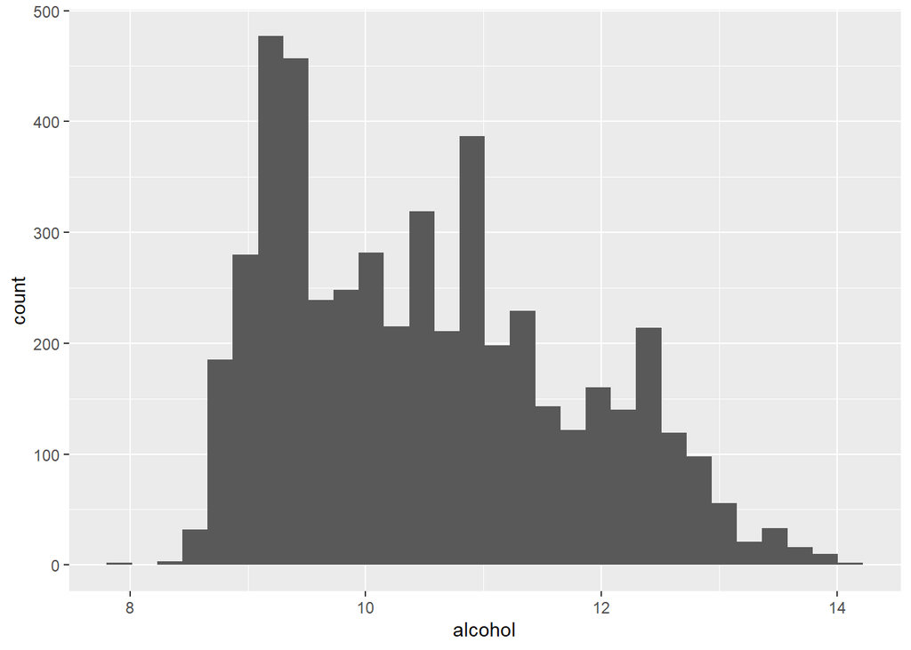

> Alcohol is one of the variables I am most curious about. There are some varieties of wine that have more alcohol, like a port which is also very sweet. While this study is on white wines, I wonder if we will see the sugar content have a postive correlation with alcohol to balance out the taste. I also wonder how this impacts the quality rating. The median wine is 10.4, and the average is 10.51, so the measurements of center are very close.

```
##    Min. 1st Qu.  Median    Mean 3rd Qu.    Max.
##    8.00    9.50   10.40   10.51   11.40   14.20
```

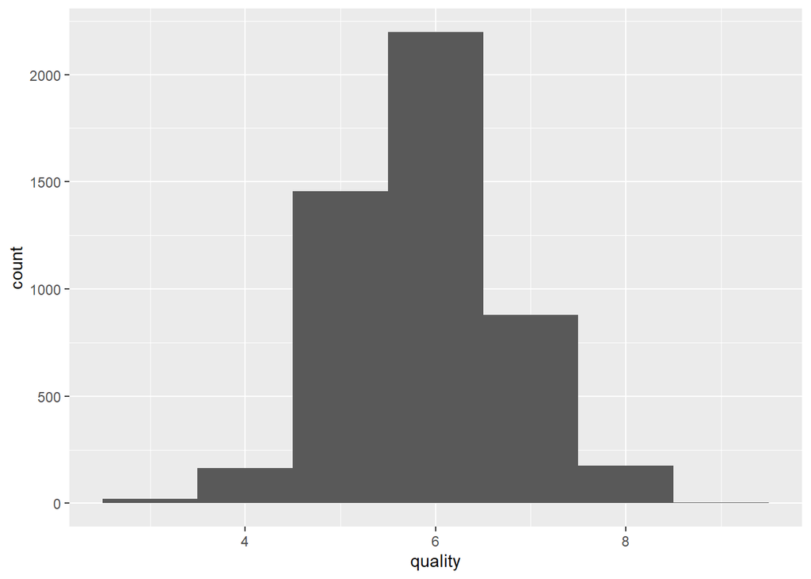

```
##    Min. 1st Qu.  Median    Mean 3rd Qu.    Max.
##   3.000   5.000   6.000   5.878   6.000   9.000
```

# Univariate Analysis

### What is the structure of your dataset?

> The data set is 4898 records, 13 columns and in tidy format.

### What is/are the main feature(s) of interest in your dataset?

> The main features of interest is what variables would make wine rank higher in quality. After the univariate analysis, the three variables that are the most interesting to me are the total sulfur dioxide, alcohol and residual sugar and their impact on quality.

### What other features in the dataset do you think will help support your

investigation into your feature(s) of interest? > I think some of the variables that don’t show a direct correlation to the quality will start to show an impact when layered with other variables.

### Did you create any new variables from existing variables in the dataset?

> I am going to create a categorical ranking from the quality in the next section. I did create a variable for a subset of the data frame for sulfur over 50mg since under that is mentioned that it is not detectable.

# Bivariate Plots Section

```
##                                 X fixed.acidity volatile.acidity  citric.acid
## X                     1.000000000   -0.25581431      0.002857966 -0.149899918
## fixed.acidity        -0.255814305    1.00000000     -0.022697290  0.289180698
## volatile.acidity      0.002857966   -0.02269729      1.000000000 -0.149471811
## citric.acid          -0.149899918    0.28918070     -0.149471811  1.000000000
## residual.sugar        0.006623775    0.08902070      0.064286060  0.094211624
## chlorides            -0.045645192    0.02308564      0.070511571  0.114364448
## free.sulfur.dioxide  -0.011928911   -0.04939586     -0.097011939  0.094077221
## total.sulfur.dioxide -0.161979037    0.09106976      0.089260504  0.121130798
## density              -0.185976097    0.26533101      0.027113845  0.149502571
## pH                   -0.115774132   -0.42585829     -0.031915368 -0.163748211
## sulphates             0.009807759   -0.01714299     -0.035728147  0.062330940
## alcohol               0.213656245   -0.12088112      0.067717943 -0.075728730
## quality               0.035763247   -0.11366283     -0.194722969 -0.009209091
##                      residual.sugar   chlorides free.sulfur.dioxide
## X                       0.006623775 -0.04564519       -0.0119289106
## fixed.acidity           0.089020701  0.02308564       -0.0493958591
## volatile.acidity        0.064286060  0.07051157       -0.0970119393
## citric.acid             0.094211624  0.11436445        0.0940772210
## residual.sugar          1.000000000  0.08868454        0.2990983537
## chlorides               0.088684536  1.00000000        0.1013923521
## free.sulfur.dioxide     0.299098354  0.10139235        1.0000000000
## total.sulfur.dioxide    0.401439311  0.19891030        0.6155009650
## density                 0.838966455  0.25721132        0.2942104109
## pH                     -0.194133454 -0.09043946       -0.0006177961
## sulphates              -0.026664366  0.01676288        0.0592172458
## alcohol                -0.450631222 -0.36018871       -0.2501039415
## quality                -0.097576829 -0.20993441        0.0081580671
##                      total.sulfur.dioxide     density            pH
## X                            -0.161979037 -0.18597610 -0.1157741316
## fixed.acidity                 0.091069756  0.26533101 -0.4258582910
## volatile.acidity              0.089260504  0.02711385 -0.0319153683
## citric.acid                   0.121130798  0.14950257 -0.1637482114
## residual.sugar                0.401439311  0.83896645 -0.1941334540
## chlorides                     0.198910300  0.25721132 -0.0904394560
## free.sulfur.dioxide           0.615500965  0.29421041 -0.0006177961
## total.sulfur.dioxide          1.000000000  0.52988132  0.0023209718
## density                       0.529881324  1.00000000 -0.0935914935
## pH                            0.002320972 -0.09359149  1.0000000000
## sulphates                     0.134562367  0.07449315  0.1559514973
## alcohol                      -0.448892102 -0.78013762  0.1214320987
## quality                      -0.174737218 -0.30712331  0.0994272457
##                         sulphates     alcohol      quality
## X                     0.009807759  0.21365624  0.035763247
## fixed.acidity        -0.017142985 -0.12088112 -0.113662831
## volatile.acidity     -0.035728147  0.06771794 -0.194722969
## citric.acid           0.062330940 -0.07572873 -0.009209091
## residual.sugar       -0.026664366 -0.45063122 -0.097576829
## chlorides             0.016762884 -0.36018871 -0.209934411
## free.sulfur.dioxide   0.059217246 -0.25010394  0.008158067
## total.sulfur.dioxide  0.134562367 -0.44889210 -0.174737218
## density               0.074493149 -0.78013762 -0.307123313
## pH                    0.155951497  0.12143210  0.099427246
## sulphates             1.000000000 -0.01743277  0.053677877
## alcohol              -0.017432772  1.00000000  0.435574715
## quality               0.053677877  0.43557472  1.000000000
```

> Most of the variables do not show a strong correlation with quality, which is not that surprising. I originally thought that it would be a combination of variables. If one variable had such a strong correlation on quality, we probably would not see as much of a range, as it would most likely be more of a standard amount added (unless cost was a major factor). I was suprised that alcohol had the strongest correlation to quality on its own. Another surprise, is the correlation with density. I assumed this would be close to 0 but it’s actually stronger than more after alcohol.I’ll explore that in another graph.

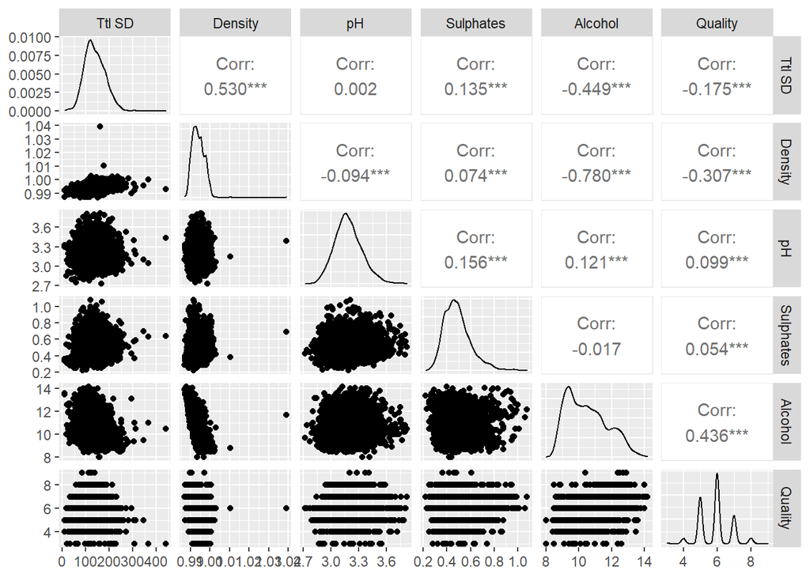

```
## $title
## [1] "Correlation Matrix"
##
## attr(,"class")
## [1] "labels"
```

> This correlation matrix allows us to see some of the more interesting correlations and plots. The strongest correlation is the negative correlation between density and alcohol.We start to see that even in the small scatterplot but we will explore that more in another section.

```
##
##  Pearson's product-moment correlation
##
## data:  wine$alcohol and wine$residual.sugar
## t = -35.321, df = 4896, p-value < 2.2e-16
## alternative hypothesis: true correlation is not equal to 0
## 95 percent confidence interval:
##  -0.4726723 -0.4280267
## sample estimates:
##        cor
## -0.4506312
```

> I had wanted to see the correlation between alcohol and sugar. I had assumed that as the alcohol content went up, more sugar would be added to help balance the strong taste. There is actually a negative correlation instead. After seeing this graph, it makes more sense that the sugar is left behind by the fermentation process, not added for taste.

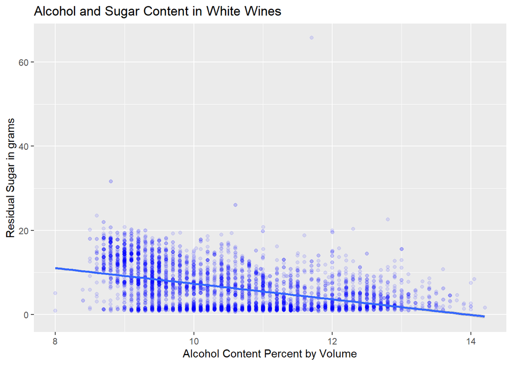

> I was surprised to see the negative correlation between alcohol and sugar content. The higher the alcohol, generally the lower the sugar. It’s possible that is because people that typically don’t enjoy wine would want something lighter and sweeter, like a wine cooler, in addition to the ferementation process itself.This does not show causation between the variables, only that a negative relationship exists.

```
##   X fixed.acidity volatile.acidity citric.acid residual.sugar chlorides
## 1 1           7.0             0.27        0.36           20.7     0.045
## 2 2           6.3             0.30        0.34            1.6     0.049
## 3 3           8.1             0.28        0.40            6.9     0.050
## 4 4           7.2             0.23        0.32            8.5     0.058
## 5 5           7.2             0.23        0.32            8.5     0.058
## 6 6           8.1             0.28        0.40            6.9     0.050
##   free.sulfur.dioxide total.sulfur.dioxide density   pH sulphates alcohol
## 1                  45                  170  1.0010 3.00      0.45     8.8
## 2                  14                  132  0.9940 3.30      0.49     9.5
## 3                  30                   97  0.9951 3.26      0.44    10.1
## 4                  47                  186  0.9956 3.19      0.40     9.9
## 5                  47                  186  0.9956 3.19      0.40     9.9
## 6                  30                   97  0.9951 3.26      0.44    10.1
##   quality quality_cat
## 1       6        Good
## 2       6        Good
## 3       6        Good
## 4       6        Good
## 5       6        Good
## 6       6        Good
```

> I’ve added a variable to categorize the wine into buckets based on quality. This is based on my own ideas and not listed in the explanation of the data set . The data set lists 1 as very poor, and 10 as very excellent, but there are no values at either of those numbers so those were not included.

> Poor is listed as anything with a rating of less than 4 in this new dataframe. In this data set, that would only include a rating of 3. Normal is 4 and 5. Good is 6 and 7. Anything 8 and over is excellent (The range of this data set is 3 to 9.)

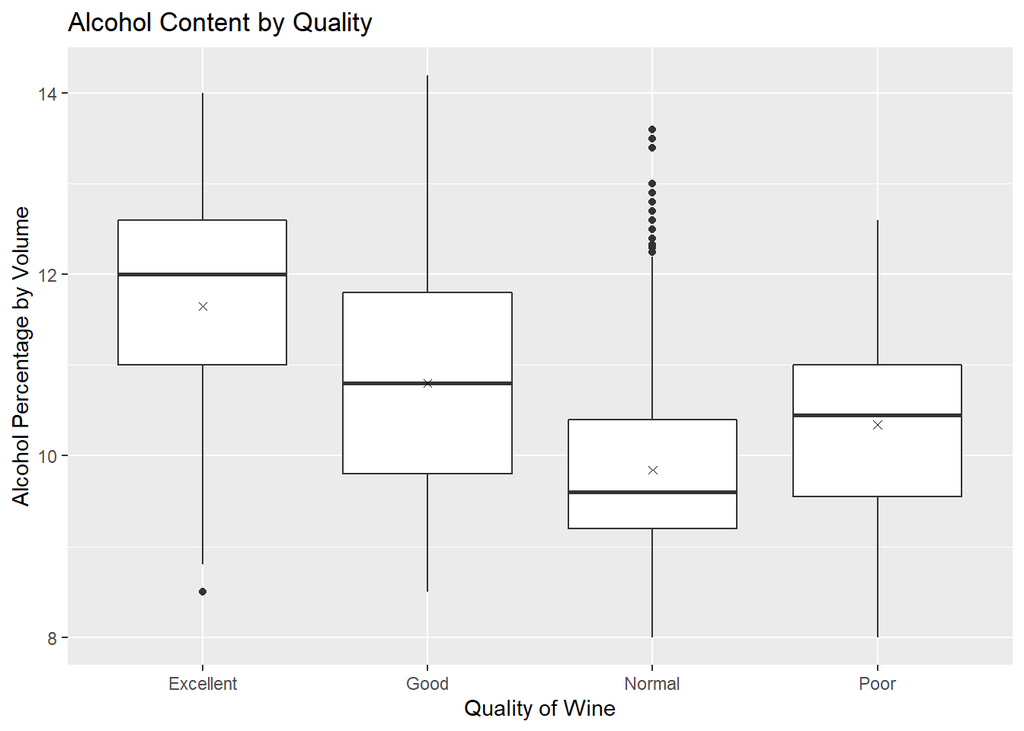

> This is interesting, because excellent quality wines clearly have a higher average and range of alcohol percentage by volume than the other categories. Good has the largest range of values, but is still more alcohol on average than normal and poor wines. In the normal category, wines have a lower alcohol content on average than the good, but there is a string of outliers that have a very high content. Finally, Poor does have more alcohol on average than normal.

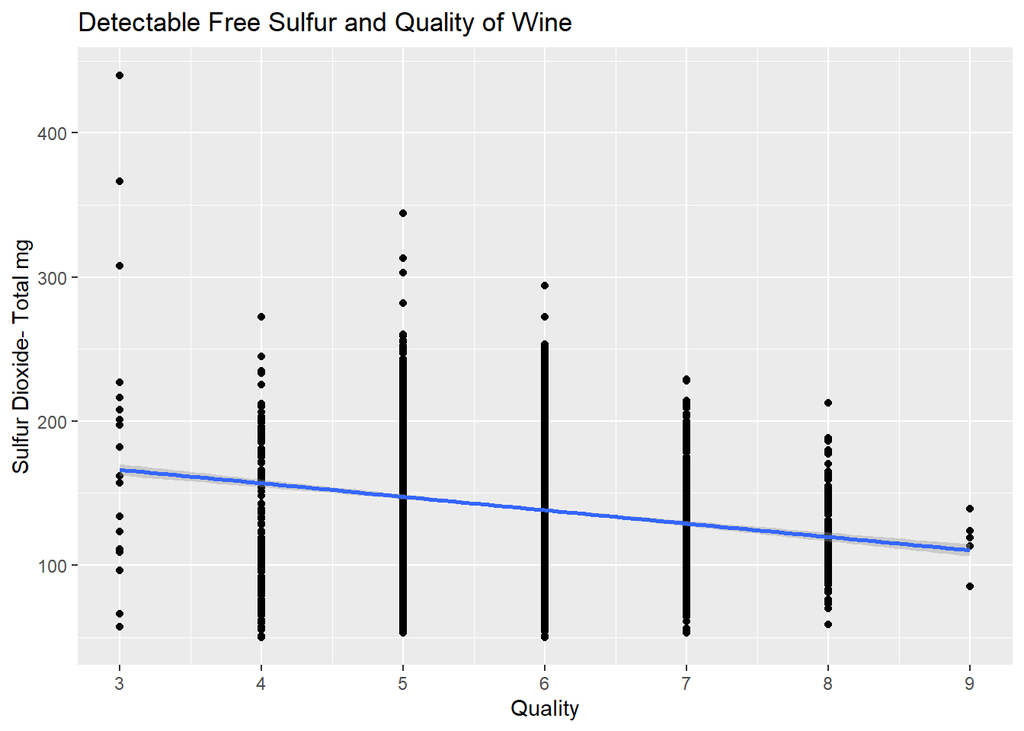

>In this plot, I limited the data to detectable sulfur, which according to the text was over 50 mg.Once we limit it to detectable values we can see there is a negative correlation between the quality and amount of total sulfur. We can see that the outliers with large amounts of sulfur dioxide are rated very low (3), while the highest rating of 9 generally has low amounts. We can’t say that total sulfur dioxide causes the ratings to decrease without an experiment.

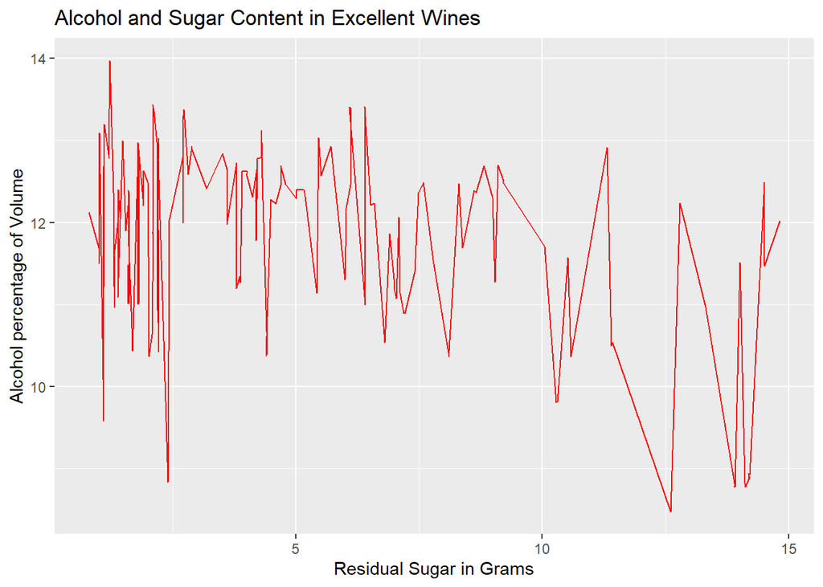

> This plot subsets the wine table to look at alcohol and sugar content only on excellent wines (8 or above). Below, this shows there are 180 records and the mean alcohol is a little higher while the mean sugar is a littler lower. The sugar max is only 14 for excellent wines.

```
## [1] "Records & Columns in Excellent Wine Data Frame:"
```

```
## [1] 180  13
```

```
## [1] "Mean & Median of Residual Sugar Content of All Wines:"
```

```
## [1] 6.391415
```

```
## [1] 5.2
```

```
## [1] "Summary of Residual Sugar of Excellent Only"
```

```
##    Min. 1st Qu.  Median    Mean 3rd Qu.    Max.
##   0.800   2.075   4.300   5.628   8.150  14.800
```

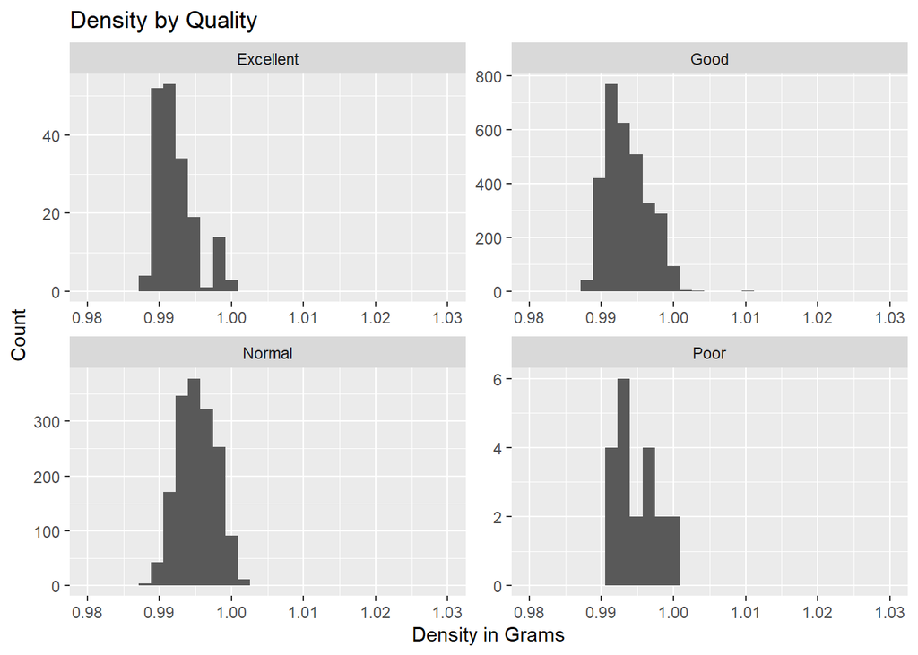

```
##    Min. 1st Qu.  Median    Mean 3rd Qu.    Max.
##  0.9871  0.9917  0.9937  0.9940  0.9961  1.0390
```

```
##
##  Pearson's product-moment correlation
##
## data:  wine_quality$density and wine_quality$quality
## t = -22.581, df = 4896, p-value < 2.2e-16
## alternative hypothesis: true correlation is not equal to 0
## 95 percent confidence interval:
##  -0.3322718 -0.2815385
## sample estimates:
##        cor
## -0.3071233
```

> Although it was not strong, there was a negative correlation between the quality and density. In this graph, by the categories, it appears most appear in the same range. We will have to explore this in more detail in the multivariate plots.

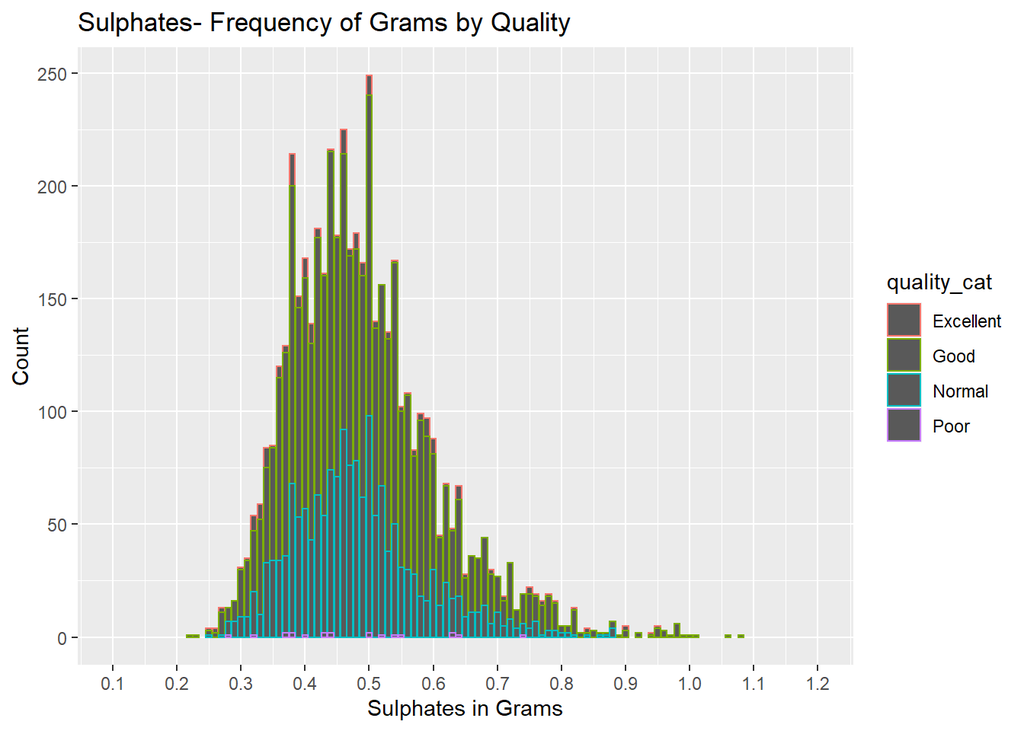

```
##    Min. 1st Qu.  Median    Mean 3rd Qu.    Max.
##  0.2200  0.4100  0.4700  0.4898  0.5500  1.0800
```

> The median for sulphates is .47 across all groups. Because it is not added to enhance the quality, I didn’t expect it to have an impact on quality. However, because it is one of the variables that I often hear mentioned, I wanted to see if it did have an impact. From this graph, it is likely that sulphates do not have an impact on quality.

# Bivariate Analysis

### Talk about some of the relationships you observed in this part of the

investigation. How did the feature(s) of interest vary with other features in  
the dataset? > In this section, I observed that the strongest correlation on quality was alcohol. There was also a negative correlation between the total sulfur and quality, once only the detectable sulfur was observed.

### Did you observe any interesting relationships between the other features

(not the main feature(s) of interest)? >There was a negative correlation between sugar and alcohol. This is especially intersting since there is a direct correlation between alcohol and quality.

### What was the strongest relationship you found?

# Multivariate Plots Section

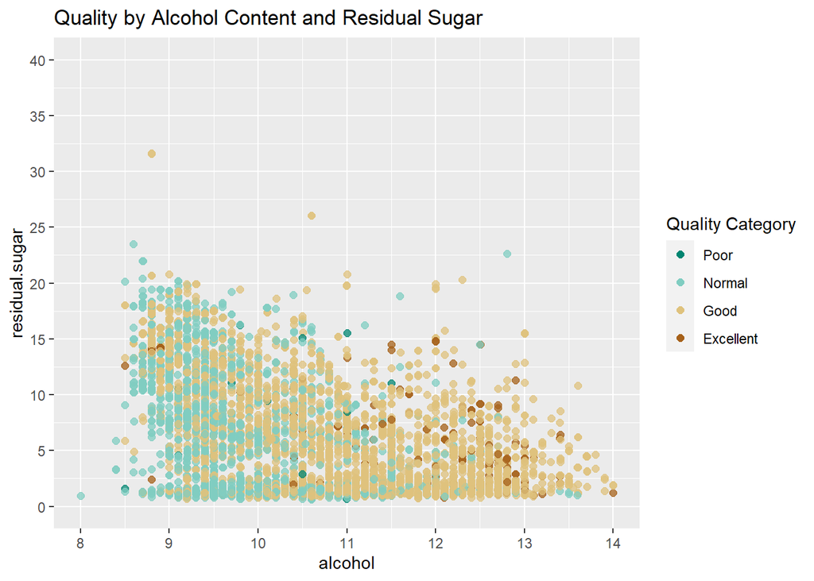

> The excellent wines tend to have more alcohol and less sugar. The alcohol is more of a factor than the sugar.

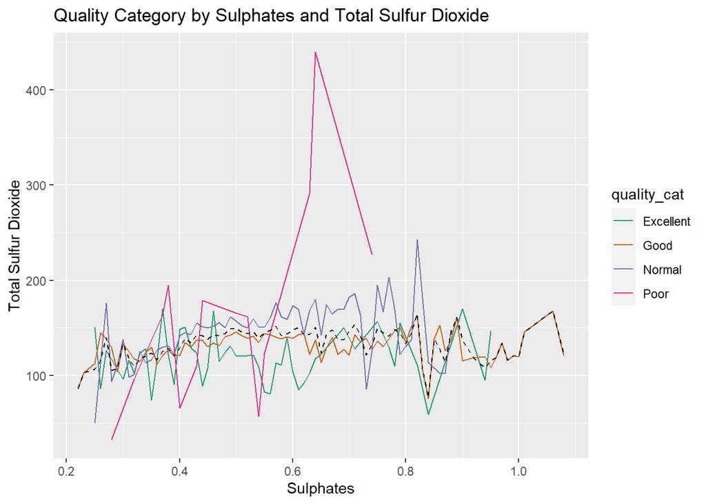

```
##
##  Pearson's product-moment correlation
##
## data:  wine_quality$sulphates and wine_quality$total.sulfur.dioxide
## t = 9.5019, df = 4896, p-value < 2.2e-16
## alternative hypothesis: true correlation is not equal to 0
## 95 percent confidence interval:
##  0.1069590 0.1619585
## sample estimates:
##       cor
## 0.1345624
```

> There is an extremely weak positive correlation between total sulfur dioxide and sulphates. Both are not added to enhance quality, but only to keep the wine safe to drink and preserve it. According to this chart, we can’t see any impact on the quality from sulphates, but we can see that any of the total sulfur well over the averages tends to be rated poor.

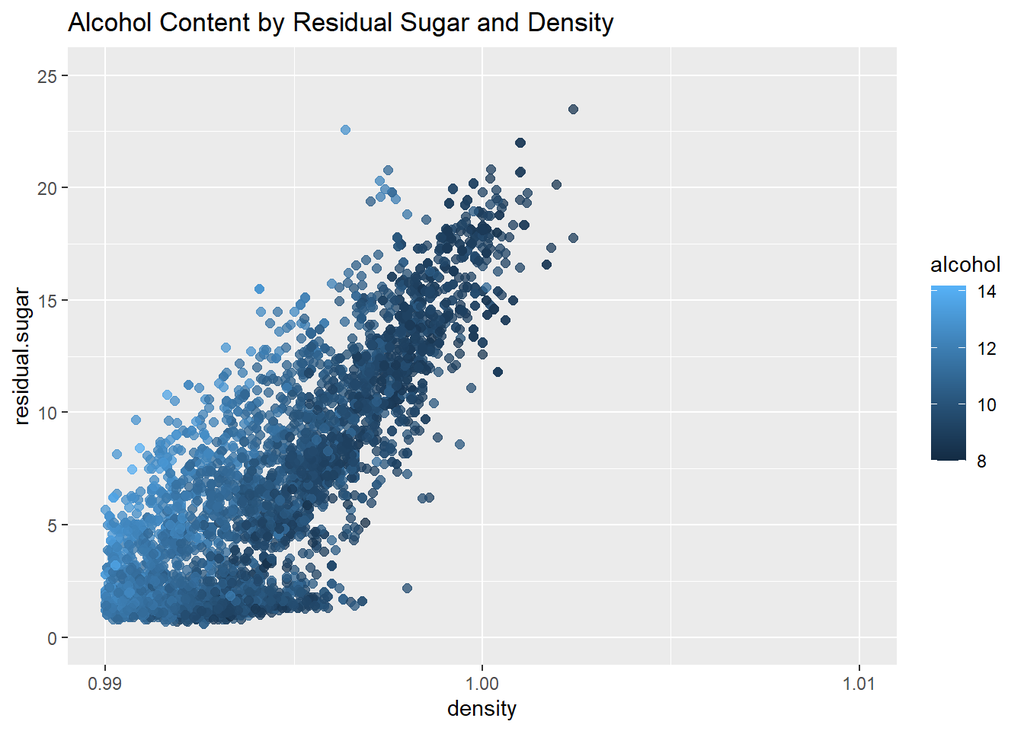

> In the original analysis, the density seemed that such a small range (equivalent to the range of water) would be hard to detect. However, it did show some correlation to the other variables. This plot limits the range to take out the outliers. This shows that as the density and sugar increases, the alcohol content tends to decrease.

```
##
## Calls:
## q1: lm(formula = I(density) ~ I(alcohol), data = wine)
## q2: lm(formula = I(density) ~ I(alcohol) + residual.sugar, data = wine)
## q3: lm(formula = I(density) ~ I(alcohol) + pH, data = wine)
## q4: lm(formula = I(density) ~ I(alcohol) + residual.sugar + sulphates,
##     data = wine)
##
## ======================================================================
##                       q1           q2           q3           q4
## ----------------------------------------------------------------------
##   (Intercept)        1.014***     1.005***     1.014***     1.003***
##                     (0.000)      (0.000)      (0.001)      (0.000)
##   I(alcohol)        -0.002***    -0.001***    -0.002***    -0.001***
##                     (0.000)      (0.000)      (0.000)      (0.000)
##   residual.sugar                  0.000***                  0.000***
##                                  (0.000)                   (0.000)
##   pH                                           0.000
##                                               (0.000)
##   sulphates                                                 0.002***
##                                                            (0.000)
## ----------------------------------------------------------------------
##   R-squared          0.609        0.907        0.609        0.913
##   N               4898         4898         4898         4898
## ======================================================================
##   Significance: *** = p < 0.001; ** = p < 0.01; * = p < 0.05
```

> Despite the correlation of alcohol and quality, I was unable to create a model that was strong enough to predict quality based on alcohol. However, the R-value is very strong for predicting density, based on alcohol and residual sugar, and even stronger if sulphates are added.

# Multivariate Analysis

### Talk about some of the relationships you observed in this part of the

investigation. Were there features that strengthened each other in terms of  
looking at your feature(s) of interest? It takes sugar to make alcohol, so it did not surprise me that there was a relationship there. It surprised me that R value was not strong when those were used. There was a relationship between density, residual sugar and alcohol.

### Were there any interesting or surprising interactions between features?

I was very surprised to see that the density when combined with alcohol seemed to impact the quality. The density range was so small and equivalent to the range of water at different temperatures, so I didn’t think that would be detectable.

### OPTIONAL: Did you create any models with your dataset? Discuss the

strengths and limitations of your model. I was unable to find a model to predict the quality. I am curious about the data set. Price is missing, so I think that these features should be checked in a similar price range (all wines about $20), or price should be included.

# Final Plots and Summary

### Plot One

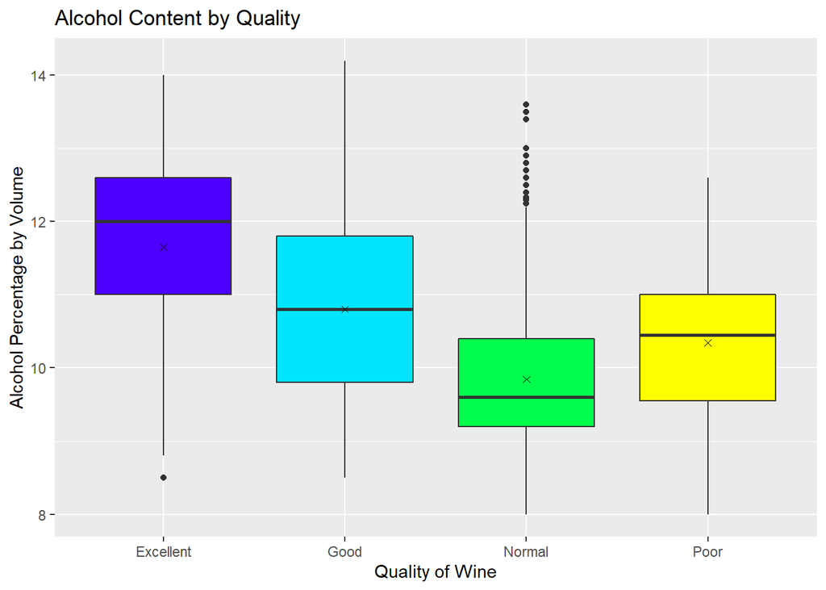

### Description One

> This box plot shows the quality of wine and percentage of Alcohol by Volume. The median increases across normal, good and excellent wines. Poor wines have more alcohol by mean and median than normal wines. The average also increases at normal and up. The normal quality group has the most outliers. This information could be used to create another model excluding poor quality to predict quality by alcohol content.

### Plot Two

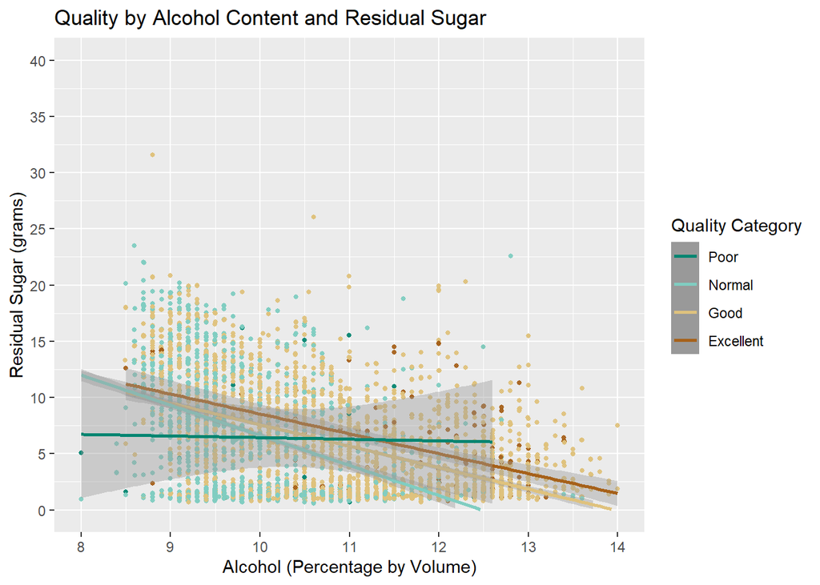

### Description Two

> This graph shows the relationship between sugar and alcohol and how they were rated by category. Breaking the wines into groups by rating, helps to show that as the alcohol increases, the sugar tends to decrease and the rating tends to increase. While this seems to happen in most categories, the poor category doesn’t react to these variables like the other categories.

### Plot Three

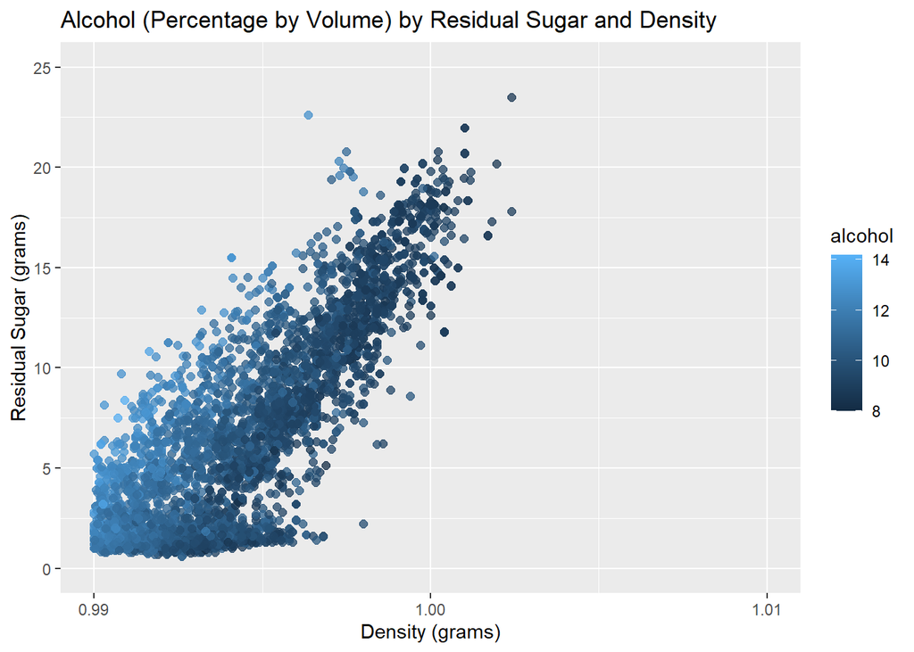

### Description Three

> This graph shows the relationship between alcohol, sugar and density. These were the strongest of the correlations that I found between variables. As the density and sugar increase, the alcohol decreases.

# Reflection

> In this analysis, the strongest relationships I found were from sugar, alcohol and density. I expected sugar and alcohol to have a correlation with quality, but I was surprised it wasn’t stronger. It was unexpected that density would be related. There were some variables like total sulfuric dioxide that should not have impacted the taste of the wine but did show changes related to quality in the detectable range.  
> I think this data range should either contain wines of the same price range, or it should include the price. While amounts of variables were measured, quality of the grapes or ingredients were not. I would suspect an $800 bottle of wine would rate much higher than a $10 bottle with similar sugar, alcohol and density amounts but it is not possible to tell with this analysis. This data set could be used create an algorithm for people to answer a few questions on preferences and then create a suggestion list. It could be used by a grocery store to feature certain wines that would rate higher with more consumers.

### Sites Used:

https://stackoverflow.com/questions/21560389/non-numeric-argument-to-binary-operator  
https://community.rstudio.com/t/creating-a-new-variable-under-conditions-of-other-two-variables/51825  
https://www.py4u.net/discuss/868741  
https://statisticsbyjim.com/regression/interpret-r-squared-regression/